# Práctica 4

## El turismo en España

En esta práctica vamos a trabajar con los datos de las pernoctaciones del año 2021 en España

### Preparación para visualizar los datos

```python
url = "https://www.ine.es/jaxi/files/_px/es/csv_bdsc/t11/e162eoap/a2017/01nad02.csv"
```

```python
!pip install pandas
```

```python
import pandas as pd
```

```python
df = pd.read_csv(url, delimiter=';')
```

### Visualización de datos

Lo primero que vamos a hacer es visualizar los datos para ver qué tipo de datos tenemos para poder decidir cómo tratalos y analizarlos.

```python
df
```

|  | Comunidades y ciudades autónomas | País de residencia | Meses | Total |
| --- | --- | --- | --- | --- |
| 0 | Total | Total | Total | 78.148.452 |
| 1 | Total | Total | Enero | 4.293.216 |
| 2 | Total | Total | Febrero | 4.232.211 |
| 3 | Total | Total | Marzo | 4.635.353 |
| 4 | Total | Total | Abril | 5.599.062 |
| ... | ... | ... | ... | ... |
| 7535 | Melilla | Resto del mundo | Agosto | 0 |
| 7536 | Melilla | Resto del mundo | Septiembre | 0 |
| 7537 | Melilla | Resto del mundo | Octubre | 0 |
| 7538 | Melilla | Resto del mundo | Noviembre | 0 |
| 7539 | Melilla | Resto del mundo | Diciembre | 0 |

7540 rows × 4 columns

```python
df.tail(10)
```

|  | Comunidades y ciudades autónomas | País de residencia | Meses | Total |
| --- | --- | --- | --- | --- |
| 7530 | Melilla | Resto del mundo | Marzo | 0 |
| 7531 | Melilla | Resto del mundo | Abril | 0 |
| 7532 | Melilla | Resto del mundo | Mayo | 0 |
| 7533 | Melilla | Resto del mundo | Junio | 0 |
| 7534 | Melilla | Resto del mundo | Julio | 0 |
| 7535 | Melilla | Resto del mundo | Agosto | 0 |
| 7536 | Melilla | Resto del mundo | Septiembre | 0 |
| 7537 | Melilla | Resto del mundo | Octubre | 0 |
| 7538 | Melilla | Resto del mundo | Noviembre | 0 |
| 7539 | Melilla | Resto del mundo | Diciembre | 0 |

```python
df.info()
```

```
<class 'pandas.core.frame.DataFrame'>
RangeIndex: 7540 entries, 0 to 7539
Data columns (total 4 columns):
 #   Column                            Non-Null Count  Dtype
---  ------                            --------------  -----
 0   Comunidades y ciudades autónomas  7540 non-null   object
 1   País de residencia                7540 non-null   object
 2   Meses                             7540 non-null   object
 3   Total                             7540 non-null   object
dtypes: object(4)
memory usage: 235.8+ KB
```

```python
df.columns
```

```
Index(['Comunidades y ciudades autónomas', 'País de residencia', 'Meses',
       'Total'],
      dtype='object')
```

```python
df['Total'].unique()
```

```
array(['78.148.452', '4.293.216', '4.232.211', ..., '1.136', '330', '0'],
      dtype=object)
```

```python
df['Meses'].unique()
```

```
array(['Total', 'Enero', 'Febrero', 'Marzo', 'Abril', 'Mayo', 'Junio',
       'Julio', 'Agosto', 'Septiembre', 'Octubre', 'Noviembre',
       'Diciembre'], dtype=object)
```

```python
df['Comunidades y ciudades autónomas']
```

```
0         Total
1         Total
2         Total
3         Total
4         Total
         ...
7535    Melilla
7536    Melilla
7537    Melilla
7538    Melilla
7539    Melilla
Name: Comunidades y ciudades autónomas, Length: 7540, dtype: object
```

### Filtrado de datos

Como podemos ver hay una gran cantidad de datos, por lo que si fuéramos a realizar un gráfico con todos ellos este no nos aportaría ninguna información porque estaría demasiado saturado. Además los propios datos se pisarían entre ellos dentro del propio gráfico. Por ejemplo, el total nacional ya incluye dentro de sus números a las comunidades autónomas por lo que no tendría mucho sentido tratarlos en un mismo análisis de datos. Por ello, hemos decidido centrar el análisis en el número de pernoctaciones totales, sin distinguir entre comunidades autónomas y así poder centrarnos en la procedencia de los viajeros, es decir, en la variable "País de residencia".

Ncesitamos quedarnos con las observaciones que hacen referencia al Total nacional, es decir, aquellas en las que en la variable "Comunidades y ciudades autónomas" tengan como valor "Total". Para ello vamos a utilizar las herramientas de filtrado condicional de pandas. Fuente: https://pandas.pydata.org/docs/getting_started/intro_tutorials/03_subset_data.html

```python
df_filtrado = df[(df['Comunidades y ciudades autónomas'] == 'Total')]
```

```python
df_filtrado['Comunidades y ciudades autónomas']
```

```
0      Total
1      Total
2      Total
3      Total
4      Total
       ...
372    Total
373    Total
374    Total
375    Total
376    Total
Name: Comunidades y ciudades autónomas, Length: 377, dtype: object
```

Pedimos la información de lo que hay dentro de la variable "País de Residencia" para decidir qué análisis vamos a llevar a cabo.

```python
df['País de residencia'].unique()
```

```
array(['Total', 'Residentes en España', 'No residentes en España',
       'Unión Europea (sin España)', 'Alemania', 'Austria', 'Bélgica',
       'Dinamarca', 'Finlandia', 'Francia', 'Grecia', 'Irlanda', 'Italia',
       'Luxemburgo', 'Países Bajos', 'Polonia', 'Portugal', 'Reino Unido',
       'Republica Checa', 'Suecia', 'Resto de la UE', 'Noruega', 'Rusia',
       'Suiza', 'Resto de Europa', 'Estados Unidos', 'Resto de América',
       'Países Africanos', 'Resto del mundo'], dtype=object)
```

Tras ver los datos hemos decidido que el primer análisis que vamos a hacer va a ser la comparativa entre el turismo nacional y extanjero. Para ello tenemos que volver a filtrar. En este caso le pedimos a Python que nos selecciones las observaciones de los residentes en españa y los no residentes, estos dentro de la variable "País de residencia". En este caso introducimos dos condiciones a la hora de seleccionar los datos, los separamos por el operador lógico "|" para indicar que se cumpla una de las condiciones.

```python
df_procedencia = df_filtrado[(df_filtrado['País de residencia'] == "Residentes en España") | (df_filtrado['País de residencia'] == "No residentes en España")]
```

```python
df_procedencia
```

|  | Comunidades y ciudades autónomas | País de residencia | Meses | Total |
| --- | --- | --- | --- | --- |
| 13 | Total | Residentes en España | Total | 19.582.452 |
| 14 | Total | Residentes en España | Enero | 650.999 |
| 15 | Total | Residentes en España | Febrero | 649.497 |
| 16 | Total | Residentes en España | Marzo | 738.082 |
| 17 | Total | Residentes en España | Abril | 1.530.402 |
| 18 | Total | Residentes en España | Mayo | 1.172.680 |
| 19 | Total | Residentes en España | Junio | 1.985.335 |
| 20 | Total | Residentes en España | Julio | 3.539.791 |
| 21 | Total | Residentes en España | Agosto | 4.546.676 |
| 22 | Total | Residentes en España | Septiembre | 2.079.239 |
| 23 | Total | Residentes en España | Octubre | 1.073.590 |
| 24 | Total | Residentes en España | Noviembre | 661.329 |
| 25 | Total | Residentes en España | Diciembre | 954.832 |
| 26 | Total | No residentes en España | Total | 58.566.000 |
| 27 | Total | No residentes en España | Enero | 3.642.217 |
| 28 | Total | No residentes en España | Febrero | 3.582.714 |
| 29 | Total | No residentes en España | Marzo | 3.897.271 |
| 30 | Total | No residentes en España | Abril | 4.068.659 |
| 31 | Total | No residentes en España | Mayo | 4.684.963 |
| 32 | Total | No residentes en España | Junio | 5.734.458 |
| 33 | Total | No residentes en España | Julio | 7.305.970 |
| 34 | Total | No residentes en España | Agosto | 7.827.107 |
| 35 | Total | No residentes en España | Septiembre | 5.871.454 |
| 36 | Total | No residentes en España | Octubre | 5.069.085 |
| 37 | Total | No residentes en España | Noviembre | 3.565.363 |
| 38 | Total | No residentes en España | Diciembre | 3.316.739 |

Como queremos graficarlo temporalmente vamos a quitar la observación anual de cada tipo de residente. Para ello volvemos a hacer uso de un condicional, esta vez utilizando el indicador lógico "!=" que viene a pedir que se seleccionen aquellos valores que sean distintos al indicado, en este caso "Total".

```python
df_final = df_procedencia[(df_procedencia['Meses'] != "Total")]
```

```python
df_final
```

|  | Comunidades y ciudades autónomas | País de residencia | Meses | Total |
| --- | --- | --- | --- | --- |
| 14 | Total | Residentes en España | Enero | 650.999 |
| 15 | Total | Residentes en España | Febrero | 649.497 |
| 16 | Total | Residentes en España | Marzo | 738.082 |
| 17 | Total | Residentes en España | Abril | 1.530.402 |
| 18 | Total | Residentes en España | Mayo | 1.172.680 |
| 19 | Total | Residentes en España | Junio | 1.985.335 |
| 20 | Total | Residentes en España | Julio | 3.539.791 |
| 21 | Total | Residentes en España | Agosto | 4.546.676 |
| 22 | Total | Residentes en España | Septiembre | 2.079.239 |
| 23 | Total | Residentes en España | Octubre | 1.073.590 |
| 24 | Total | Residentes en España | Noviembre | 661.329 |
| 25 | Total | Residentes en España | Diciembre | 954.832 |
| 27 | Total | No residentes en España | Enero | 3.642.217 |
| 28 | Total | No residentes en España | Febrero | 3.582.714 |
| 29 | Total | No residentes en España | Marzo | 3.897.271 |
| 30 | Total | No residentes en España | Abril | 4.068.659 |
| 31 | Total | No residentes en España | Mayo | 4.684.963 |
| 32 | Total | No residentes en España | Junio | 5.734.458 |
| 33 | Total | No residentes en España | Julio | 7.305.970 |
| 34 | Total | No residentes en España | Agosto | 7.827.107 |
| 35 | Total | No residentes en España | Septiembre | 5.871.454 |
| 36 | Total | No residentes en España | Octubre | 5.069.085 |
| 37 | Total | No residentes en España | Noviembre | 3.565.363 |
| 38 | Total | No residentes en España | Diciembre | 3.316.739 |

### Elaboración del gráfico

Como queremos elaborar el gráfico en función de la fecha vamos a identificar nuestras entradas por los "Meses".

```python
df_final.set_index('Meses')
```

| Meses | Comunidades y ciudades autónomas | País de residencia | Total |
| --- | --- | --- | --- |
| Enero | Total | Residentes en España | 650.999 |
| Febrero | Total | Residentes en España | 649.497 |
| Marzo | Total | Residentes en España | 738.082 |
| Abril | Total | Residentes en España | 1.530.402 |
| Mayo | Total | Residentes en España | 1.172.680 |
| Junio | Total | Residentes en España | 1.985.335 |
| Julio | Total | Residentes en España | 3.539.791 |
| Agosto | Total | Residentes en España | 4.546.676 |
| Septiembre | Total | Residentes en España | 2.079.239 |
| Octubre | Total | Residentes en España | 1.073.590 |
| Noviembre | Total | Residentes en España | 661.329 |
| Diciembre | Total | Residentes en España | 954.832 |
| Enero | Total | No residentes en España | 3.642.217 |
| Febrero | Total | No residentes en España | 3.582.714 |
| Marzo | Total | No residentes en España | 3.897.271 |
| Abril | Total | No residentes en España | 4.068.659 |
| Mayo | Total | No residentes en España | 4.684.963 |
| Junio | Total | No residentes en España | 5.734.458 |
| Julio | Total | No residentes en España | 7.305.970 |
| Agosto | Total | No residentes en España | 7.827.107 |
| Septiembre | Total | No residentes en España | 5.871.454 |
| Octubre | Total | No residentes en España | 5.069.085 |
| Noviembre | Total | No residentes en España | 3.565.363 |
| Diciembre | Total | No residentes en España | 3.316.739 |

```python
df_final.set_index('Meses')['Total']
```

```
Meses
Enero           650.999
Febrero         649.497
Marzo           738.082
Abril         1.530.402
Mayo          1.172.680
Junio         1.985.335
Julio         3.539.791
Agosto        4.546.676
Septiembre    2.079.239
Octubre       1.073.590
Noviembre       661.329
Diciembre       954.832
Enero         3.642.217
Febrero       3.582.714
Marzo         3.897.271
Abril         4.068.659
Mayo          4.684.963
Junio         5.734.458
Julio         7.305.970
Agosto        7.827.107
Septiembre    5.871.454
Octubre       5.069.085
Noviembre     3.565.363
Diciembre     3.316.739
Name: Total, dtype: object
```

```python
df_final.set_index('Meses')['Total'].plot()
```

[output not shown]

### Convertir variable

Cuando hemos pedido la descripción de las variables a través de df.info() no nos hemos dado cuenta de que la variable "Total" no era numérica, sino "object" que podemos traducirla como "categórica" o "nominal". Para solucionar el problema hemos buscado cómo cambiar una variable "object" a una "numeric". La función que según statoloy.org (https://www.statology.org/pandas-typeerror-no-numeric-data-to-plot/) consigue hacer esto es .astype().

```python
df_final['Total']=df_final['Total'].astype(float)
```

[output not shown]

```python
df_final['Total']
```

```
14      650.999
15      649.497
16      738.082
17    1.530.402
18    1.172.680
19    1.985.335
20    3.539.791
21    4.546.676
22    2.079.239
23    1.073.590
24      661.329
25      954.832
27    3.642.217
28    3.582.714
29    3.897.271
30    4.068.659
31    4.684.963
32    5.734.458
33    7.305.970
34    7.827.107
35    5.871.454
36    5.069.085
37    3.565.363
38    3.316.739
Name: Total, dtype: object
```

El error que nos aparece al tratar de aplicar esta función es que Python confunde el número con una cadena de caracteres por los puntos separadores de los miles. Por ello, para conseguir una variable numérica debemos deshacernos de los puntos. Para ello intentamos utilizar la función ".replace()" que tal y como explica la guía de pandas, sirve para reemplazar unos caracteres por otros. Así, le pedimos que nos cambie los puntos, por nada y así eliminarlos. Fuente: https://pandas.pydata.org/docs/reference/api/pandas.DataFrame.replace.html

```python
df_final['Total']=df_final['Total'].replace(".", "")
```

```python
df_final['Total']
```

```
14      650.999
15      649.497
16      738.082
17    1.530.402
18    1.172.680
19    1.985.335
20    3.539.791
21    4.546.676
22    2.079.239
23    1.073.590
24      661.329
25      954.832
27    3.642.217
28    3.582.714
29    3.897.271
30    4.068.659
31    4.684.963
32    5.734.458
33    7.305.970
34    7.827.107
35    5.871.454
36    5.069.085
37    3.565.363
38    3.316.739
Name: Total, dtype: object
```

Vemos que esta función tampoco ha funcionado porque al visualizar la variable "Total" nos siguen apareciendo los puntos. Por esta razón buscamos otra manera de solucionar este problema utilizando las funciones de pandas. Utilizamos las funciones "str.split()" y "str.join()" para primero, separar la cadena de caracteres en el punto y posteriormente unirlas ahora sin el punto.

Fuente: https://pandas.pydata.org/docs/reference/api/pandas.Series.str.split.html Series.str.split: Split strings around given separator/delimiter. Series.str.join: Join lists contained as elements in the Series/Index with passed delimiter.

```python
df_final['Total'] = df_final['Total'].str.split('.').str.join("")
```

Ahora que tenemos los números sin el punto volvemos a pedir que nos transforme la variable que sigue siendo nominal, a una variable numérica con la función utilizada anteriormente:

```python
df_final['Total'] = df_final['Total'].str.split('.').str.join("").astype('float')
```

```python
df_final
```

|  | Comunidades y ciudades autónomas | País de residencia | Meses | Total |
| --- | --- | --- | --- | --- |
| 14 | Total | Residentes en España | Enero | 650999.0 |
| 15 | Total | Residentes en España | Febrero | 649497.0 |
| 16 | Total | Residentes en España | Marzo | 738082.0 |
| 17 | Total | Residentes en España | Abril | 1530402.0 |
| 18 | Total | Residentes en España | Mayo | 1172680.0 |
| 19 | Total | Residentes en España | Junio | 1985335.0 |
| 20 | Total | Residentes en España | Julio | 3539791.0 |
| 21 | Total | Residentes en España | Agosto | 4546676.0 |
| 22 | Total | Residentes en España | Septiembre | 2079239.0 |
| 23 | Total | Residentes en España | Octubre | 1073590.0 |
| 24 | Total | Residentes en España | Noviembre | 661329.0 |
| 25 | Total | Residentes en España | Diciembre | 954832.0 |
| 27 | Total | No residentes en España | Enero | 3642217.0 |
| 28 | Total | No residentes en España | Febrero | 3582714.0 |
| 29 | Total | No residentes en España | Marzo | 3897271.0 |
| 30 | Total | No residentes en España | Abril | 4068659.0 |
| 31 | Total | No residentes en España | Mayo | 4684963.0 |
| 32 | Total | No residentes en España | Junio | 5734458.0 |
| 33 | Total | No residentes en España | Julio | 7305970.0 |
| 34 | Total | No residentes en España | Agosto | 7827107.0 |
| 35 | Total | No residentes en España | Septiembre | 5871454.0 |
| 36 | Total | No residentes en España | Octubre | 5069085.0 |
| 37 | Total | No residentes en España | Noviembre | 3565363.0 |
| 38 | Total | No residentes en España | Diciembre | 3316739.0 |

### Gráfico

Ahora que ya tenemos los datos como variable numérica deberíamos poder realizar el gráfico.

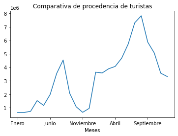

```python
df_final.set_index('Meses')['Total'].plot(title = "Comparativa de procedencia de turistas")
```

En este gráfico lo que nos ocurre es que los valores "Residentes" y "No residentes" están representados como si fueran dos años en lugar de situar los dos en el mismo año pero en dos líneas diferentes y no nos permite comparar la afluencia turística que era nuestro objetivo. Por ello, tenemos que pedirle a Python que represente los valores en función de la variable "País de Residencia." Para ello vamos a utilizar la función ".groupby()". Fuente: https://pandas.pydata.org/docs/reference/api/pandas.DataFrame.groupby.html

```
País de residencia
No residentes en España    AxesSubplot(0.125,0.125;0.775x0.755)
Residentes en España       AxesSubplot(0.125,0.125;0.775x0.755)
Name: Total, dtype: object
```

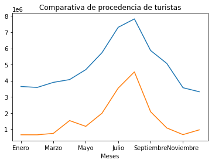

```python
df_final.set_index('Meses').groupby('País de residencia')['Total'].plot(title = "Comparativa de procedencia de turistas")
```

En este gráfico hemos conseguido que los residentes y no residentes aparezcan de forma diferenciada, pero no sabemos qué línea pertece a cada grupo. Para ello vamos a incluir una leyenda con atributos que configuren la función ".plot()"

```
País de residencia
No residentes en España    AxesSubplot(0.125,0.125;0.775x0.755)
Residentes en España       AxesSubplot(0.125,0.125;0.775x0.755)
Name: Total, dtype: object
```

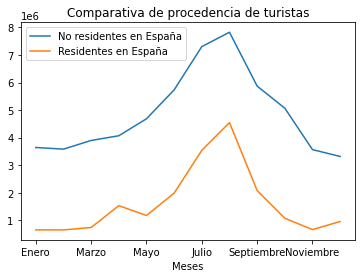

```python
df_final.set_index('Meses').groupby('País de residencia')['Total'].plot(title = "Comparativa de procedencia de turistas", legend = 1)
```

```
País de residencia
No residentes en España    AxesSubplot(0.125,0.125;0.775x0.755)
Residentes en España       AxesSubplot(0.125,0.125;0.775x0.755)
Name: Total, dtype: object
```

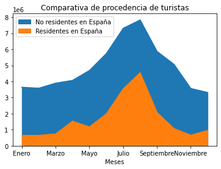

```python
df_final.set_index('Meses').groupby('País de residencia')['Total'].plot(title = "Comparativa de procedencia de turistas", legend = 1, kind = "area")
```

### Guardar la imagen:

Importamos la librería matplotlib para guardarlo porque es aquella que permite visualizar los datos en Python.

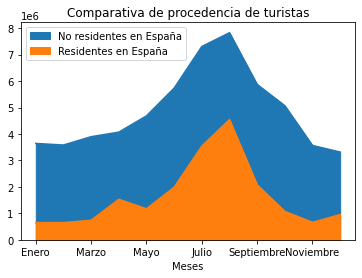

```python
import matplotlib.pyplot as plt
df_final.set_index('Meses').groupby('País de residencia')['Total'].plot(title = "Comparativa de procedencia de turistas", legend = 1, kind = "area")
plt.savefig('RvsNR.png')
```